# Meta-Analytic Pooling of CLES Estimates: A Comparison of Transformation Approaches

Bethany Hamilton Bhat and Wolfgang Viechtbauer

Department of Psychiatry and Neuropsychology, Faculty of Health, Medicine and Life Sciences, Maastricht University

8 June 2026

## Motivation

Common measures for two-group comparisons on quantitative outcomes:

- Mean differences
- Standardized mean differences ($d$)
- Log ratio of means (lnRR)
- Measures of stochastic superiority ($\theta$)

## Stochastic Superiority ($\theta$)

The probability that a randomly selected person from one group has a higher outcome than a randomly selected person from another group

$$\theta = P(Y>X)+\frac{1}{2}P(Y=X)$$

- $\frac{1}{2}P(Y=X)$ term handles ties
- Several parametric and non-parametric estimators:
  - Area Under the ROC Curve (AUC), concordance probability (c-statistic), constructed from Mann-Whitney U ($\hat{\theta} = \mathrm{U} /(n_1n_2)$), $\cdots$
  - Common Language Effect Size (CLES)

## Estimating $\theta$: CLES

- Proposed by McGraw and Wong (1992), and under normality and homoscedasticity: $\theta = \Phi\left(\frac{\mu_Y - \mu_X}{\sqrt{2 \sigma^2}}\right)$
- Under these assumptions, $d$ completely determines any measure of overlap between two distributions

$$\hat{\theta} = \Phi\left(\frac{d}{\sqrt{2}}\right), \quad \mathrm{var}(\hat{\theta}) = \frac{e^{-d^2 / 2}}{4\pi} \left(\frac{1}{n_1} + \frac{1}{n_2} + \frac{d^2}{2(n_1+n_2)} \right)$$

- There is no comprehensive evaluation on how to best pool CLES estimates

## Meta-analyzing CLES Estimates

- CLES:
  - $\hat{\theta} \in [0, 1]$
  - Sampling distribution is skewed near 0 and 1
- Three transformations of $\hat{\theta}_i$:
  - logit, arcsine, and probit/SMD
- Two back-transformations to obtain $\hat{\mu}_{\theta}$:
  - Standard
  - Integral

## Back-transformation Methods for $\hat{\mu}_{\theta}$

Two approaches to estimate $\mu_{\theta}$ after pooling on the transformed scale:

- Standard:
  - Returns the **median** of the distribution of true effects, not the mean (Jensen’s inequality)
- Integral:
  - Integrates $g^{-1}$ over the normal random-effects distribution
  - Recovers the **mean** of the distribution of true effects
  - See Igelmann et al. (2026)

## Data Generation

$$n_i \sim (\overline{n}/20) \times \chi_{df=4}^2 + (3\overline{n}/10),$$

where $\overline{n}$ is the average sample size for a primary study and assuming equal group sizes

3. Generated observed CLES estimates ($\hat{\theta}_i$) implied by the model that
- Assumed normally distributed outcomes with equal population variances
- $\sigma_X = \sigma_Y = 1$ and $\mu_X = 0$
- $\mu_Y$ chosen so that $P(Y>X)=\theta_i$

## Simulation Design

| Factor | Values |
| --- | --- |
| CLES parameter ($\mu_{\theta}$) | 0.5, 0.555, 0.635, 0.710, 0.776, 0.833 |
| Number of studies ($k$) | 10, 20, 40, 80, 160 |
| Avg. participants per study ($\bar{n}$) | 30, 50, 80, 100 |
| Between-study heterogeneity ($\tau_{\theta}$) | 0, 0.012, 0.048, 0.094, 0.138 |

- 600 conditions $\times$ 10,000 replications each
- $\mu_{\theta}$ and $\tau_{\theta}$ choosen to correspond to commonly observed SMD values
- 7 pooling methods; REML estimation (DL when convergence failed); Knapp-Hartung test
- Performance criteria: bias and RMSE of $\hat{\mu}_{\theta}$; 95% CI coverage; rejection rates and power for test of $H_0: \mu_{\theta} = 0.5$ and Q-test of $H_0: \tau^2 = 0$; bias in $\hat{\tau}_{\theta}$

## Results: Parameter Bias

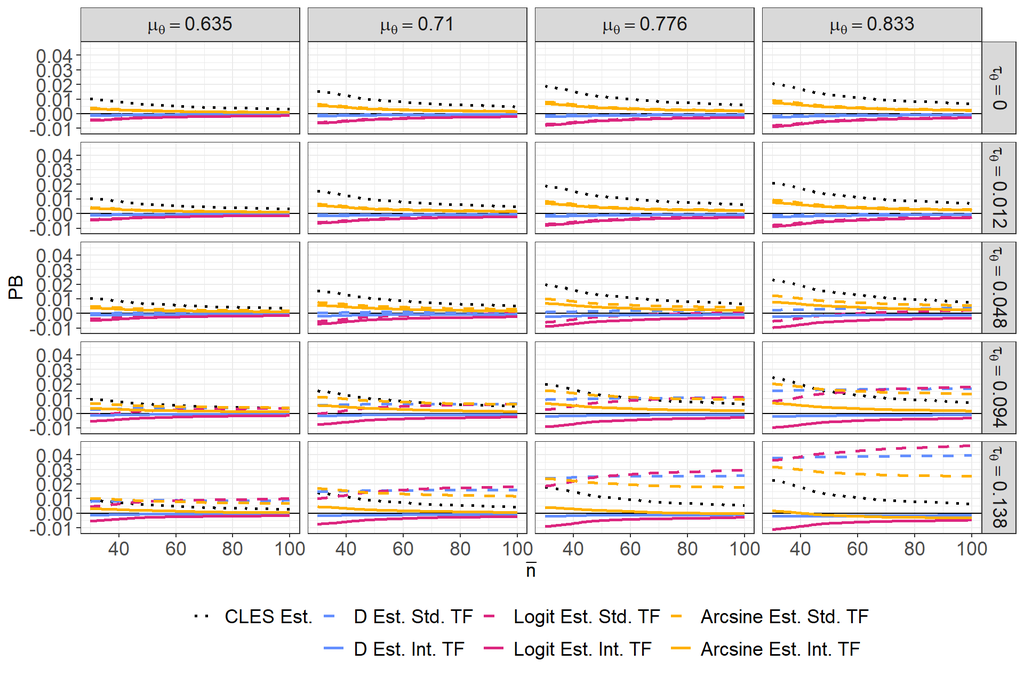

## Results: RMSE

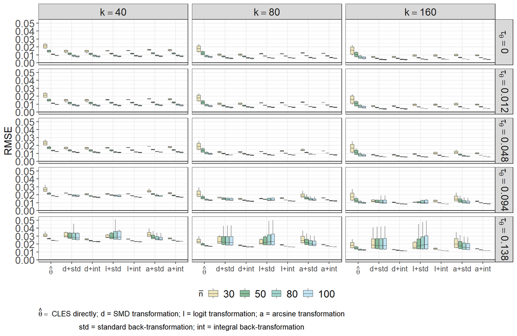

## Results: Coverage

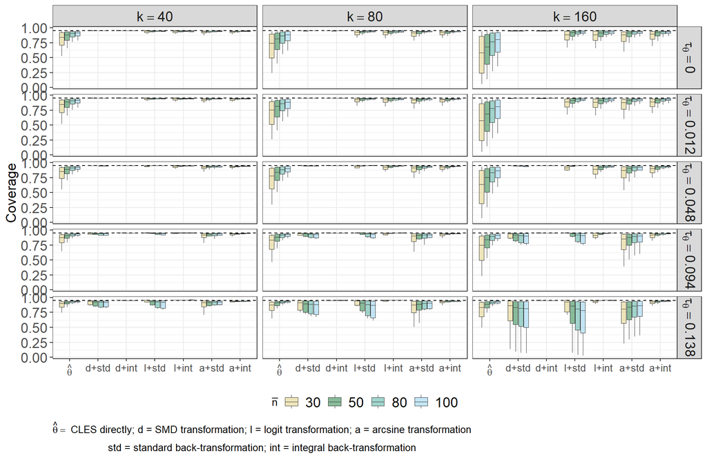

## Results: Coverage – Integral Methods Only

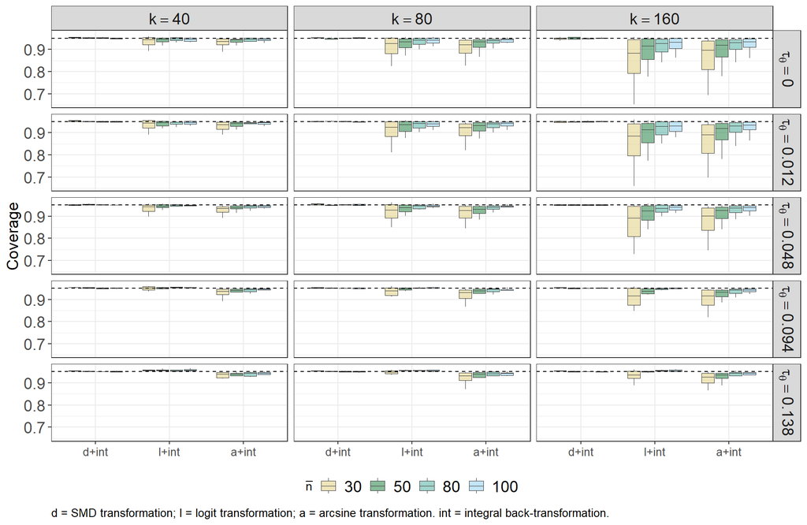

## Thank you! Questions?

## References

Cliff, Norman. 1993. “Dominance Statistics: Ordinal Analyses to Answer Ordinal Questions.” *Psychological Bulletin* 114 (3): 494–509. https://doi.org/10.1037/0033-2909.114.3.494.

DeLong, Elizabeth R., David M. DeLong, and Daniel L. Clarke-Pearson. 1988. “Comparing the Areas Under Two or More Correlated Receiver Operating Characteristic Curves: A Nonparametric Approach.” *Biometrics* 44 (3): 837–45. https://doi.org/10.2307/2531595.

Hanley, J. A., and B. J. McNeil. 1982. “The Meaning and Use of the Area Under a Receiver Operating Characteristic (ROC) Curve.” *Radiology* 143 (1): 29–36. https://doi.org/doi: 10.1148/radiology.143.1.7063747. PMID: 7063747.

Igelmann, Jan-Bernd, Markus Pauly, and Wolfgang Viechtbauer. 2026. “Back-Transformations in Random-Effects Meta-Analysis—Impact and Interpretation.” *Research Synthesis Methods*, May, 1–14. https://doi.org/10.1017/rsm.2026.10096.

Marín-Martínez, Fulgencio, and Julio Sánchez-Meca. 1998. “Testing for Dichotomous Moderators in Meta-Analysis.” *The Journal of Experimental Education* 67 (1): 69–81. https://www.jstor.org/stable/20152582.

McGraw, Kenneth O., and S. P. Wong. 1992. “A Common Language Effect Size Statistic.” *Psychological Bulletin* (US) 111 (2): 361–65. https://doi.org/10.1037/0033-2909.111.2.361.

Newson, Roger. 2002. “Parameters Behind ‘Nonparametric’ Statistics: Kendall’s Tau, Somers’ D and Median Differences.” *The Stata Journal* 2 (1): 45–64. https://doi.org/10.1177/1536867X0200200103.

Sanchez-Meca, Julio, and Fulgencio Marin-Martinez. 1998. “Weighting by Inverse Variance or by Sample Size in Meta-Analysis: A Simulation Study.” *Educational and Psychological Measurement* 58 (2): 211–19.

## Extra Slides

## Transformations of CLES Estimates

Direct Transformations, Back-transformations, and Sampling Variances

| Transformation | $g(\hat{\theta})$ | $g^{-1}(t)$ | $\mathrm{var}(g(\hat{\theta}))$ |
| --- | --- | --- | --- |
| Logit | $\ln\left(\dfrac{\hat{\theta}}{1-\hat{\theta}}\right)$ | $\dfrac{1}{1+e^{-t}}$ | $\dfrac{1}{\hat{\theta}^2(1-\hat{\theta})^2} \times \mathrm{var}(\hat{\theta})$ |
| Arcsine | $\arcsin\left(\sqrt{\hat{\theta}}\right)$ | $\sin^2(t)$ | $\dfrac{1}{4\hat{\theta}(1-\hat{\theta})} \times \mathrm{var}(\hat{\theta})$ |
| Probit | $\Phi^{-1}(\hat{\theta})$ | $\Phi(t)$ | $\dfrac{1}{\left[\phi(\Phi^{-1}(\hat{\theta}))\right]^2} \times \mathrm{var}(\hat{\theta})$ |
| SMD | $\Phi^{-1}(\hat{\theta})\sqrt{2}$ | $\Phi\left(\dfrac{t}{\sqrt{2}}\right)$ | $\dfrac{1}{n_1} + \dfrac{1}{n_2} + \dfrac{d^2}{2(n_1+n_2)}$ |

## Back-transformation Methods

Integral Back-Transformations for Each Method

| Transformation | Integral |
| --- | --- |
| Logit | $\displaystyle\int_{-\infty}^{\infty} \dfrac{1}{1+e^{-t}} \, \phi(t \mid \mu, \tau^2) \, dt$ |
| Arcsine | $\displaystyle\int_{0}^{\pi/2} \sin^2(t) \, \dfrac{\phi(t \mid \mu, \tau^2)}{\Phi\left(\frac{\pi/2-\mu}{\tau}\right) - \Phi\left(\frac{-\mu}{\tau}\right)} \, dt$ |
| Probit | $\displaystyle\int_{-\infty}^{\infty} \Phi(t) \, \phi(t \mid \mu, \tau^2) \, dt$ |
| SMD | $\displaystyle\int_{-\infty}^{\infty} \Phi\left(\dfrac{t}{\sqrt{2}}\right) \phi(t \mid \mu, \tau^2) \, dt$ |

## Beta Distributions

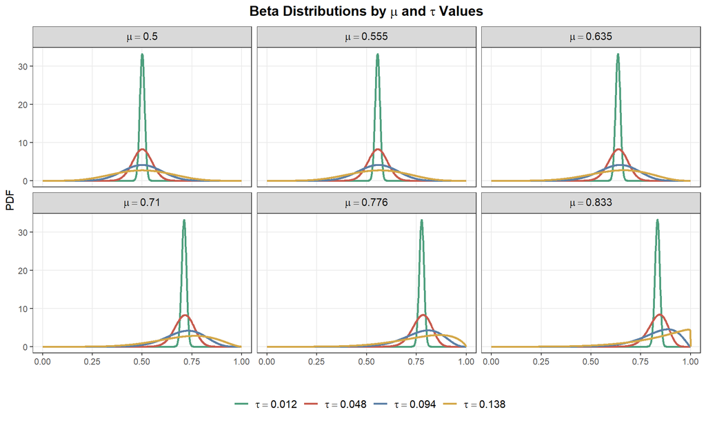

## Obtaining CLES Estimates

1. After obtaining true CLES values, then transform to true SMD values:

$$g_{\text{d}}(\theta_i) = \Phi^{-1}(\theta_i)\sqrt{2}$$

3. Generate observed SMD estimates from a scaled non-central $t$-distribution assuming homoscedastic variances:

$$g_{\text{d}}(\hat{\theta_i}) \sim N\left(g_{\text{d}}(\theta_i), \sqrt{\frac{1}{n_1} + \frac{1}{n_2}}\right) \bigg/ \sqrt{\frac{\chi^2(df= n_1+n_2 -2)}{n_1 + n_2 -2}}$$